# Simple document

2022-09-12

```r
library(tidyverse)
```

I’m an R Markdown document! I’m making a change

# Section 1

Here’s a **code chunk** that samples from a *normal distribution*:

```r
samp = rnorm(100)
length(samp)
```

```
## [1] 100
```

I can take the mean of the sample, too! The mean is -0.0582803.

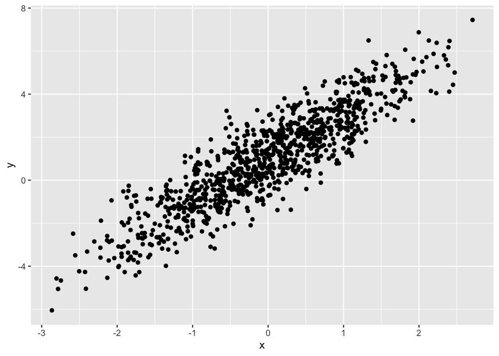

# Customize Code Chunks:

`eval = FALSE`: code will be displayed but not executed; results are not included.

echo = FALSE: code will be executed but not displayed; results are included.

include = FALSE: code won’t be executed or displayed.

message = FALSE and warning = FALSE: prevents messages and warnings from being displayed.

results = hide and fig.show = hide: prevents results and figures from being shown, respectively.

collapse = TRUE: output will be collapsed into a single block at shown at the end of the chunk.

error: errors in code will stop rendering when FALSE; errors in code will be printed in the doc when TRUE. The default is FALSE and you should almost never change it.

```r
df <- tibble(
x = rnorm(500, mean = 1),
y = (x > 0),
z = abs(x)
)


med = median(df$z)
```

The median of the absolute values is 1.

- The mean of the sample is 0.954904.
- The median of the sample is 0.9700929.
- The standard deviation of the sample is 0.9942557.

# Formatting Text

## Text formatting

*italic* or *italic* **bold** or **bold** `code` superscript<sup>2</sup> and subscript<sub>2</sub>

# 1st Level Header

## 2nd Level Header

### 3rd Level Header

## Lists

- Bulleted list item 1
- Item 2
  - Item 2a
  - Item 2b
1. Numbered list item 1
2. Item 2. The numbers are incremented automatically in the output.

## Tables

| First Header | Second Header |
| --- | --- |
| Content Cell | Content Cell |
| Content Cell | Content Cell |

# YAML & Output Formats

author: “Jeff Goldsmith” date: 2019-09-10

output: html_document: toc: true toc_float: true

output: pdf_document: default

output: word_document: default